# 1 Setup and reproducibility

# 15 Double DQN on Env V2

Introduces Double DQN to reduce overestimation bias present in standard DQN when working with Env V2. It splits the action selection and action evaluation steps between the online and target networks when computing Bellman targets. The training loop mirrors the basic DQN implementation but uses the Double DQN target formula and logs the evolution of episode returns.

```
a*  = argmax_a Q_online(s', a)
y   = r + γ (1 - done) Q_target(s', a*)
```

After training, Double DQN is evaluated in the same way as the other policies, and its mean cost and risk measures are added to the comparison tables. The section shows whether the more cautious value estimation improves stability or tail behavior for the clinic scheduling problem.

```
[DDQN-V2] step=  4000 episodes= 125 last_return= 919.36
[DDQN-V2] step=  8000 episodes= 250 last_return=1328.08
[DDQN-V2] step= 12000 episodes= 375 last_return=1080.04
[DDQN-V2] step= 16000 episodes= 500 last_return=1604.82
[DDQN-V2] step= 20000 episodes= 625 last_return=1255.77
[DDQN-V2] step= 24000 episodes= 750 last_return=2008.75
[DDQN-V2] step= 28000 episodes= 875 last_return=1341.29
[DDQN-V2] step= 32000 episodes=1000 last_return=1488.88
[DDQN-V2] step= 36000 episodes=1125 last_return=1732.95
[DDQN-V2] step= 40000 episodes=1250 last_return=2118.77
Saved: report_artifacts/ddqn_rewards_envv2_20251124_211404.png
                policy  mean_cost_v2  mean_cost_v2_ci_lo  mean_cost_v2_ci_hi  \
1                 ddqn  -1346.245361        -1401.005005        -1288.222046
2                  dqn  -1346.245361        -1401.005005        -1288.222046
4          no_overbook  -1346.245361        -1401.005005        -1288.222046
5               random    -89.358589         -174.958771           -4.218270
3        mild_overbook    -33.649994         -118.113251           45.052849
0  aggressive_overbook     -5.478119          -96.615623           78.094322

       var5_v2     cvar5_v2     served  mean_revenue  mean_shortfall_penalty
1  -483.875000  -223.915375  52.980469   2649.023438              211.054688
2  -483.875000  -223.915375  52.980469   2649.023438              211.054688
4  -483.875000  -223.915375  52.980469   2649.023438              211.054688
5  1109.625000  1371.207764  59.925781   2996.289062               41.132812
3  1037.949951  1345.976685  59.925781   2996.289062               40.781250
0  1319.750000  1539.192261  60.011719   3000.585938               36.914062
Saved: report_artifacts/ecdf_envv2_ddqn_20251124_211410.png
```

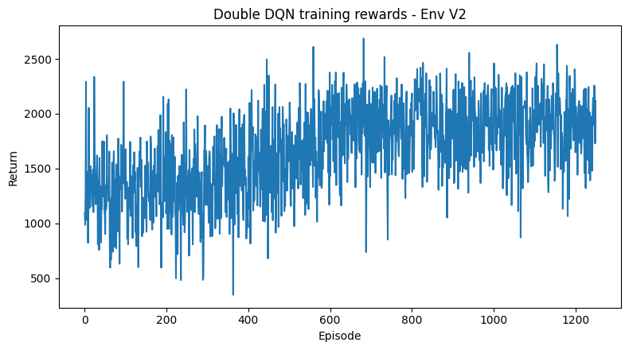

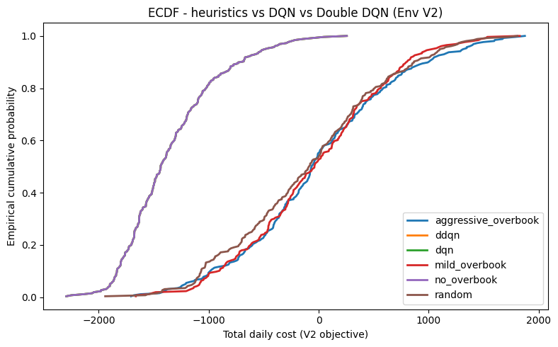

```python
def train_step_ddqn(qnet: QNet,
                    tgt: QNet,
                    opt: torch.optim.Optimizer,
                    batch,
                    gamma: float = 0.99) -> float:
    """
    One Double DQN update step.

    qnet: online network (used for both current Q(s,a) and argmax over Q(s',·))
    tgt : target network (used only to evaluate Q(s', a*))
    batch: (s, a, r, s2, done) sampled from replay buffer
    """
    s, a, r, s2, d = batch  # shapes as in train_step
    # Current Q(s,a) from online network
    q_sa = qnet(s).gather(1, a)

    with torch.no_grad():
        # Action selection with online network
        q_next_online = qnet(s2)                          # [B, A]
        a_star = q_next_online.argmax(dim=1, keepdim=True)  # [B, 1]

        # Action evaluation with target network
        q_next_target = tgt(s2).gather(1, a_star)         # [B, 1]

        y = r + (1.0 - d) * gamma * q_next_target        # Double DQN target

    loss = nn.functional.smooth_l1_loss(q_sa, y)
    opt.zero_grad()
    loss.backward()
    nn.utils.clip_grad_norm_(qnet.parameters(), 1.0)
    opt.step()
    return float(loss.item())


def run_ddqn_v2(env_cfg: ClinicConfig,
                steps_total: int = 40_000,
                batch_size: int = 64,
                start_learning: int = 1_000,
                target_sync: int = 2_000,
                gamma: float = 0.99,
                lr: float = 1e-3,
                print_every: int = 2_000):
    """
    Train a Double DQN agent directly on ClinicEnvV2, where the per-step
    reward already encodes the V2 objective (costs, revenue, and
    shortfall penalties). The training loop mirrors run_dqn_v2, but the
    TD updates use the Double DQN target defined above.
    """
    env = ClinicEnvV2(env_cfg)
    obs_dim = env.observation_space.shape[0]
    n_actions = env.action_space.n

    qnet = QNet(obs_dim, n_actions).to(device)
    tgt  = QNet(obs_dim, n_actions).to(device)
    tgt.load_state_dict(qnet.state_dict())

    opt = optim.Adam(qnet.parameters(), lr=lr)
    buf = ReplayBuffer(capacity=50_000)

    obs, _ = env.reset(seed=cfg.seed)
    ep_return = 0.0
    rewards = []
    losses = []
    episodes = 0

    for step in range(1, steps_total + 1):
        eps = dqn_epsilon(step,
                          eps_start=1.0,
                          eps_end=0.05,
                          eps_decay_steps=20_000)
        a = select_action(qnet, obs, env, eps)
        obs2, r, term, trunc, _ = env.step(a)
        done_flag = float(term or trunc)

        buf.push(obs.astype(np.float32), a, r, obs2.astype(np.float32), done_flag)
        obs = obs2
        ep_return += r

        if term or trunc:
            rewards.append(ep_return)
            episodes += 1
            if step % print_every == 0:
                print(f"[DDQN-V2] step={step:6d} episodes={episodes:4d} "
                      f"last_return={ep_return:7.2f}")
            ep_return = 0.0
            obs, _ = env.reset()

        if len(buf) >= start_learning:
            loss = train_step_ddqn(qnet, tgt, opt, buf.sample(batch_size), gamma=gamma)
            losses.append(loss)

        if step % target_sync == 0:
            tgt.load_state_dict(qnet.state_dict())

    logs = {
        "rewards": np.array(rewards, dtype=np.float32),
        "losses": np.array(losses, dtype=np.float32),
    }
    return qnet, logs


# Train Double DQN on Env V2
qnet_ddqn_v2, logs_ddqn_v2 = run_ddqn_v2(
    cfg,
    steps_total=40_000,
    batch_size=64,
    start_learning=1_000,
    target_sync=2_000,
    gamma=0.99,
    lr=1e-3,
    print_every=2_000,
)

# Plot training rewards for comparison with vanilla DQN
plt.figure(figsize=(8, 4.5))
plt.plot(logs_ddqn_v2["rewards"])
plt.xlabel("Episode")
plt.ylabel("Return")
plt.title("Double DQN training rewards - Env V2")
plt.tight_layout()
path_ddqn_rewards_v2 = os.path.join(ART_DIR, f"ddqn_rewards_envv2_{now_tag()}.png")
plt.savefig(path_ddqn_rewards_v2, dpi=120)
print("Saved:", path_ddqn_rewards_v2)

# Evaluate DDQN alongside heuristics (and DQN) on V2 objective
df_ddqn_v2 = evaluate_greedy_v2(qnet_ddqn_v2, cfg, episodes=256).assign(policy="ddqn")

# Heuristic baselines (and DQN from earlier section)
df_h_v2 = eval_policies_v2(cfg, POLICIES, episodes=256)
try:
    df_dqn_v2_cmp = evaluate_greedy_v2(qnet_dqn_v2, cfg, episodes=256).assign(policy="dqn")
    df_all_ddqn_v2 = pd.concat([df_h_v2, df_dqn_v2_cmp, df_ddqn_v2], ignore_index=True)
except NameError:
    df_all_ddqn_v2 = pd.concat([df_h_v2, df_ddqn_v2], ignore_index=True)

# Summarize mean and tail risk under V2
summary_ddqn_v2 = summarize_v2(df_all_ddqn_v2, alpha=0.05)
print(summary_ddqn_v2)

# ECDF of V2 total cost for heuristics vs DQN vs Double DQN
plt.figure(figsize=(8, 5))
for name, g in df_all_ddqn_v2.groupby("policy"):
    if name not in ["no_overbook", "mild_overbook", "aggressive_overbook", "random", "dqn", "ddqn"]:
        continue
    y, x = ecdf(g["cost_total_v2"].to_numpy())
    plt.plot(y, x, label=name, linewidth=2.0)
plt.xlabel("Total daily cost (V2 objective)")
plt.ylabel("Empirical cumulative probability")
plt.title("ECDF - heuristics vs DQN vs Double DQN (Env V2)")
plt.legend()
plt.tight_layout()
path_ecdf_ddqn_v2 = os.path.join(ART_DIR, f"ecdf_envv2_ddqn_{now_tag()}.png")
plt.savefig(path_ecdf_ddqn_v2, dpi=130)
print("Saved:", path_ecdf_ddqn_v2)
```